# Аналіз та прогнозування часових рядів. Лабораторна робота 3

Якушев Максим

## 1 Підготовка даних до роботи

### 1.1 Завантаження даних в R

Переглянемо загальний вигляд завантаженої бази даних. Конвертуємо стовпець Date у формат дати за допомогою функції as.Date()

```r
stock <- read.csv("Microsoft_Stock.csv", header = TRUE, sep = ",", stringsAsFactors = FALSE)
stock$Date <- as.Date(stock$Date, tryFormats = c("%Y-%m-%d", "%m/%d/%Y", "%d.%m.%Y"))

print(head(stock))
```

```
##         Date  Open  High   Low Close   Volume
## 1 2015-04-01 40.60 40.76 40.31 40.72 36865322
## 2 2015-04-02 40.66 40.74 40.12 40.29 37487476
## 3 2015-04-06 40.34 41.78 40.18 41.55 39223692
## 4 2015-04-07 41.61 41.91 41.31 41.53 28809375
## 5 2015-04-08 41.48 41.69 41.04 41.42 24753438
## 6 2015-04-09 41.25 41.62 41.25 41.48 25723861
```

### 1.2 Перевірка, що дані є часовим рядом

Переконаємось, що дані коректно розпізнані: стовпець Date має бути з типом date, а числові показники з типом integer або numeric

```r
str(stock)
```

```
## 'data.frame':    1511 obs. of  6 variables:
##  $ Date  : Date, format: "2015-04-01" "2015-04-02" ...
##  $ Open  : num  40.6 40.7 40.3 41.6 41.5 ...
##  $ High  : num  40.8 40.7 41.8 41.9 41.7 ...
##  $ Low   : num  40.3 40.1 40.2 41.3 41 ...
##  $ Close : num  40.7 40.3 41.5 41.5 41.4 ...
##  $ Volume: int  36865322 37487476 39223692 28809375 24753438 25723861 28022002 30276692 24244382 27343581 ...
```

### 1.3 Побудова графіку часового ряду

Побудуємо графік зміни ціни закриття (Close) у часі

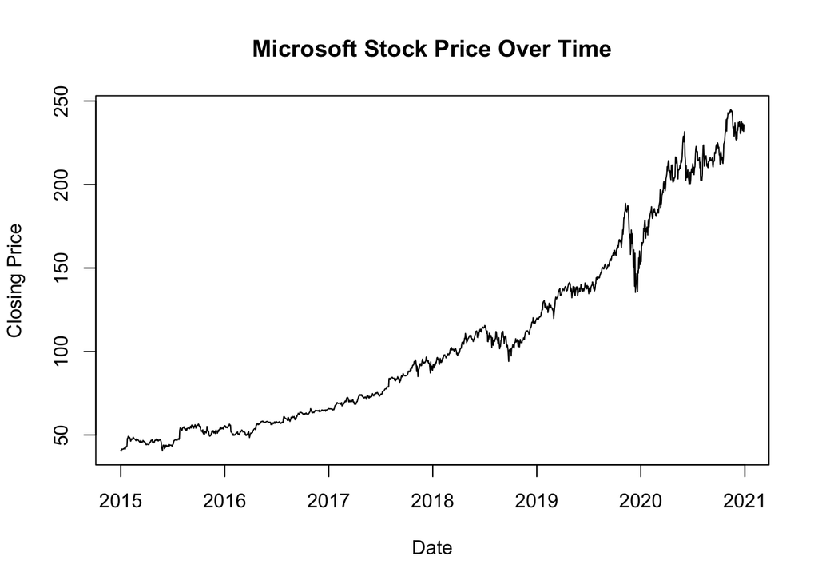

```r
msft_ts <- ts(stock$Close, frequency = 252, start = c(2015, 1))
plot(msft_ts, type = "l",
     main = "Microsoft Stock Price Over Time",
     ylab = "Closing Price", xlab = "Date", xaxt = "n")

time_values <- time(msft_ts)
year_positions <- seq(2015, 2021, by = 1)
axis(1, at = year_positions, labels = year_positions)
```

# 2 Побудова моделі з використанням спеціальних функцій пакету forecast: holt(), hw(), est()

Підключаємо пакет Forecast

```r
library(forecast)
```

Перевіримо чи існує сезонність

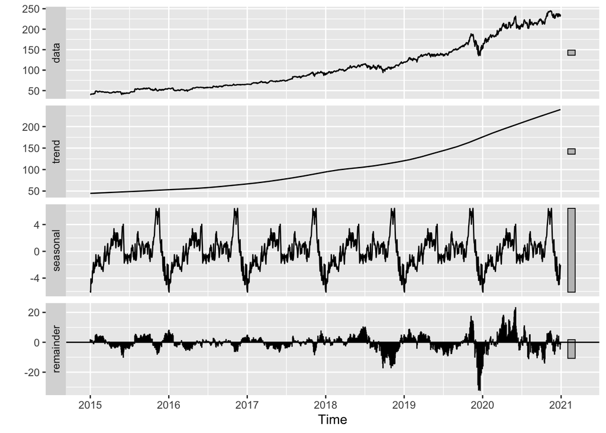

```r
stl_decomp <- stl(msft_ts, s.window = "periodic")
autoplot(stl_decomp)
```

Як можна побачати з графіка - сезонність присутня.

#### Групування даних по місяцях для побудови моделі

Щоденні дані мають частоту 252 (торгівельні дні на рік), що занадто високо для функцій `hw()`. Тому ми групуємо дані по місяцях та обчислюємо середнє, створюючи часовий ряд з частотою 12 (місяців на рік), що дозволить побудувати моделі

```r
library(dplyr)
stock_monthly <- stock %>%
  mutate(Month = format(Date, "%Y-%m")) %>%
  group_by(Month) %>%
  summarise(Close = mean(Close))

msft_ts_monthly <- ts(stock_monthly$Close, frequency = 12, start = c(2015,1))
```

### 2.1 Aдитивна модель Холта – Уінтерса з лінійним трендом

```r
hw_additive_model <- hw(msft_ts_monthly, seasonal = "additive")
hw_additive_model$model
```

```
## Holt-Winters' additive method
##
## Call:
## hw(y = msft_ts_monthly, seasonal = "additive")
##
##   Smoothing parameters:
##     alpha = 0.8946
##     beta  = 0.0655
##     gamma = 4e-04
##
##   Initial states:
##     l = 43.5556
##     b = 3.0526
##     s = -3.634 2.1762 -0.9153 -0.1783 0.6591 -0.8126
##            -0.1134 3.2161 3.1269 -0.0993 -1.0478 -2.3775
##
##   sigma:  5.9412
##
##      AIC     AICc      BIC
## 580.4206 591.7540 619.1240
```

### 2.2 Адитивна модель Холта – Уінтерса з демпфованим трендом

```r
hw_add_damped_model <- hw(msft_ts_monthly, seasonal = "additive", damped = TRUE)
hw_add_damped_model$model
```

```
## Damped Holt-Winters' additive method
##
## Call:
## hw(y = msft_ts_monthly, seasonal = "additive", damped = TRUE)
##
##   Smoothing parameters:
##     alpha = 0.8506
##     beta  = 0.0834
##     gamma = 1e-04
##     phi   = 0.98
##
##   Initial states:
##     l = 42.6048
##     b = 2.4532
##     s = -3.5664 0.9498 -0.9752 0.0541 0.5456 -1.4078
##            1.4587 3.2942 3.8136 0.2723 -0.942 -3.4969
##
##   sigma:  6.204
##
##      AIC     AICc      BIC
## 587.3557 600.2613 628.3356
```

### 2.3 Мультиплікативна модель Холта – Уінтерса з лінійним трендом

```r
hw_mult_model <- hw(msft_ts_monthly, seasonal = "multiplicative")
hw_mult_model$model
```

```
## Holt-Winters' multiplicative method
##
## Call:
## hw(y = msft_ts_monthly, seasonal = "multiplicative")
##
##   Smoothing parameters:
##     alpha = 0.527
##     beta  = 0.0437
##     gamma = 2e-04
##
##   Initial states:
##     l = 42.6529
##     b = 1.7159
##     s = 0.9453 1.0221 0.9806 0.9842 0.9912 0.9923
##            1.0103 1.0489 1.0454 1.0159 0.9927 0.9711
##
##   sigma:  0.0575
##
##      AIC     AICc      BIC
## 566.3193 577.6527 605.0227
```

### 2.4 Мультиплікативна модель Холта – Уінтерса з демпфованим трендом

```r
hw_mult_damped_model <- hw(msft_ts_monthly, seasonal = "multiplicative", damped = TRUE)
hw_mult_damped_model$model
```

```
## Damped Holt-Winters' multiplicative method
##
## Call:
## hw(y = msft_ts_monthly, seasonal = "multiplicative", damped = TRUE)
##
##   Smoothing parameters:
##     alpha = 0.8195
##     beta  = 0.1408
##     gamma = 0.0014
##     phi   = 0.9322
##
##   Initial states:
##     l = 42.5388
##     b = 2.0728
##     s = 0.952 1.0221 0.9795 0.98 0.9853 0.9818
##            1.0059 1.0372 1.0406 1.0215 1.0072 0.9871
##
##   sigma:  0.0551
##
##      AIC     AICc      BIC
## 560.3200 573.2256 601.3000
```

### 2.5 ETS-моделі Холта – Уінтерса з адитивними та мультиплікативними помилками

Де:

$A$ - адитивна компонента;

$M$ - мультиплікативна компонента;

$A_d$ - демпфований (damped) тренд.

#### ETS $(A,A,A)$

```r
ets_aaa_model <- ets(msft_ts_monthly, model = "AAA")
ets_aaa_model$par
```

```
##         alpha          beta         gamma             l             b
##  0.8945729865  0.0654957908  0.0004310666 43.5555605148  3.0526013336
##            s0            s1            s2            s3            s4
## -3.6340153969  2.1762471747 -0.9152853586 -0.1783304123  0.6591167778
##            s5            s6            s7            s8            s9
## -0.8125679418 -0.1134341171  3.2160895916  3.1268714726 -0.0993385478
##           s10
## -1.0478383298
```

```r
ets_aaa_model$sigma2
```

```
## [1] 35.29792
```

#### ETS $(A,A_d,A)$

```r
ets_aa_da_model <- ets(msft_ts_monthly, model = "AAA", damped = TRUE)
ets_aa_da_model$par
```

```
##         alpha          beta         gamma           phi             l
##  0.8505830536  0.0834087368  0.0001014795  0.9799620112 42.6047967406
##             b            s0            s1            s2            s3
##  2.4531914873 -3.5664293046  0.9497861236 -0.9751778130  0.0541404664
##            s4            s5            s6            s7            s8
##  0.5456357538 -1.4078058523  1.4586554198  3.2941799975  3.8136203114
##            s9           s10
##  0.2723233503 -0.9420450206
```

```r
ets_aa_da_model$sigma2
```

```
## [1] 38.48945
```

#### ETS $(M,A,A)$

```r
ets_maa_model <- ets(msft_ts_monthly, model = "MAA")
ets_maa_model$par
```

```
##         alpha          beta         gamma             l             b
##  0.9998520136  0.0496843503  0.0001034208 43.1807908109  1.6708172262
##            s0            s1            s2            s3            s4
## -2.6143432871 -1.0225605267 -0.0538666649  1.5012648135  2.1294975398
##            s5            s6            s7            s8            s9
## -0.0502157125 -1.1690220906  0.9896438999  0.7225569729 -0.1700660826
##           s10
##  0.4919372189
```

```r
ets_maa_model$sigma2
```

```
## [1] 0.002163254
```

#### ETS $(M,A_d,A)$

```r
ets_ma_da_model <- ets(msft_ts_monthly, model = "MAA", damped = TRUE)
ets_ma_da_model$par
```

```
##       alpha        beta       gamma         phi           l           b
##  0.99386478  0.07213730  0.00612907  0.97999422 42.28363881  1.56100601
##          s0          s1          s2          s3          s4          s5
## -5.75240037 -2.14886244 -1.36532473  0.03299406  1.22766742 -0.16185060
##          s6          s7          s8          s9         s10
##  0.58982058  3.13258538  4.14815547  2.01553763  0.06817333
```

```r
ets_ma_da_model$sigma2
```

```
## [1] 0.002994934
```

#### ETS $(M,A,M)$

```r
ets_mam_model <- ets(msft_ts_monthly, model = "MAM")
ets_mam_model$par
```

```
##       alpha        beta       gamma           l           b          s0
##  0.93875879  0.04179588  0.02949676 40.47366092  2.96946355  0.97389535
##          s1          s2          s3          s4          s5          s6
##  0.99724626  0.99502089  0.98706091  0.99513496  0.99196359  0.99250261
##          s7          s8          s9         s10
##  1.01584689  1.01992952  1.01044681  1.01089279
```

```r
ets_mam_model$sigma2
```

```
## [1] 0.002416297
```

#### ETS $(M,A_d,M)$

```r
ets_ma_dm_model <- ets(msft_ts_monthly, model = "MAM", damped = TRUE)
ets_ma_dm_model$par
```

```
##        alpha         beta        gamma          phi            l            b
## 6.737651e-01 6.488485e-02 1.017086e-04 9.799996e-01 4.281515e+01 1.345280e+00
##           s0           s1           s2           s3           s4           s5
## 9.707867e-01 1.006198e+00 9.935585e-01 9.984485e-01 1.013646e+00 1.001519e+00
##           s6           s7           s8           s9          s10
## 9.875610e-01 1.015499e+00 1.022154e+00 1.004647e+00 9.985040e-01
```

```r
ets_ma_dm_model$sigma2
```

```
## [1] 0.002526016
```

### Автопідбір моделі за допомогою функції ets()

```r
ets_auto <- ets(msft_ts_monthly)
ets_auto$par
```

```
##       alpha        beta           l           b
##  0.99989161  0.04543583 42.05370839  1.33422933
```

```r
ets_auto$sigma2
```

```
## [1] 0.001953323
```

## 3 Оцінка якості моделей та значень параметрів

Зробимо оцінку розглянутих моделей та порівняємо їх

```r
accuracy(hw_additive_model)
```

```
##                     ME    RMSE      MAE        MPE   MAPE      MASE       ACF1
## Training set 0.3491183 5.23965 3.745788 -0.2898831 3.9255 0.1165556 -0.0109502
```

```r
accuracy(hw_add_damped_model)
```

```
##                     ME    RMSE      MAE       MPE     MAPE      MASE
## Training set 0.8080844 5.42233 3.839845 0.3388529 3.984498 0.1194823
##                     ACF1
## Training set -0.01536759
```

```r
accuracy(hw_mult_model)
```

```
##                    ME     RMSE     MAE       MPE    MAPE      MASE      ACF1
## Training set 1.115553 4.717533 3.74074 0.4088685 4.08329 0.1163985 0.3478703
```

```r
accuracy(hw_mult_damped_model)
```

```
##                    ME     RMSE      MAE      MPE     MAPE      MASE       ACF1
## Training set 1.200127 4.592519 3.507897 0.800616 3.679418 0.1091533 0.08487339
```

```r
accuracy(ets_aaa_model)
```

```
##                     ME    RMSE      MAE        MPE   MAPE      MASE       ACF1
## Training set 0.3491183 5.23965 3.745788 -0.2898831 3.9255 0.1165556 -0.0109502
```

```r
accuracy(ets_aa_da_model)
```

```
##                     ME    RMSE      MAE       MPE     MAPE      MASE
## Training set 0.8080844 5.42233 3.839845 0.3388529 3.984498 0.1194823
##                     ACF1
## Training set -0.01536759
```

```r
accuracy(ets_maa_model)
```

```
##                     ME     RMSE      MAE       MPE     MAPE      MASE
## Training set 0.6831569 5.643626 3.628806 0.2559982 3.241996 0.1129156
##                    ACF1
## Training set -0.1369946
```

```r
accuracy(ets_ma_da_model)
```

```
##                     ME     RMSE      MAE      MPE     MAPE     MASE       ACF1
## Training set 0.9732589 5.537152 3.760521 0.603712 3.679626 0.117014 -0.1272361
```

```r
accuracy(ets_mam_model)
```

```
##                     ME     RMSE      MAE        MPE     MAPE      MASE
## Training set 0.4167332 5.194786 3.530525 -0.3663884 3.437953 0.1098574
##                     ACF1
## Training set -0.02643904
```

```r
accuracy(ets_ma_dm_model)
```

```
##                    ME     RMSE      MAE       MPE     MAPE      MASE      ACF1
## Training set 1.287193 5.114229 3.682809 0.8386077 3.508389 0.1145959 0.2077029
```

```r
accuracy(ets_auto)
```

```
##                     ME     RMSE      MAE       MPE     MAPE      MASE
## Training set 0.7738904 5.799553 3.548826 0.4155242 3.172697 0.1104268
##                    ACF1
## Training set -0.1727831
```

#### Таблиця результатів

|  | MAPE | MASE | $\alpha$ | $\beta$ | $\gamma$ | $\varphi$ | $\sigma$ |
| --- | --- | --- | --- | --- | --- | --- | --- |
| **Aдитивна модель Холта – Уінтерса з лінійним трендом** | 3.926% | 0.117 | 0.895 | 0.065 | 0 | - | 5.941 |
| **Адитивна модель Холта – Уінтерса з демпфованим трендом** | 3.984% | 0.119 | 0.851 | 0.083 | 0 | 0.98 | 6.204 |
| **Мультиплікативна модель Холта – Уінтерса з лінійним трендом** | 4.083% | 0.116 | 0.527 | 0.044 | 0 | - | 0.058 |
| **Мультиплікативна модель Холта – Уінтерса з демпфованим трендом** | 3.679% | 0.109 | 0.82 | 0.141 | 0.001 | 0.932 | 0.055 |
| **ETS (A,A,A)** | 3.926% | 0.117 | 0.895 | 0.065 | 0 | - | 5.941 |
| **ETS (A,Ad,A)** | 3.984% | 0.119 | 0.851 | 0.083 | 0 | 0.98 | 6.204 |
| **ETS (M,A,A)** | 3.242% | 0.113 | 1 | 0.05 | 0 | - | 0.047 |
| **ETS (M,Ad,A)** | 3.68% | 0.117 | 0.994 | 0.072 | 0.006 | 0.98 | 0.055 |
| **ETS (M,A,M)** | 3.438% | 0.11 | 0.939 | 0.042 | 0.029 | - | 0.049 |
| **ETS (M,Ad,M)** | 3.508% | 0.115 | 0.674 | 0.065 | 0 | 0.98 | 0.05 |
| **ETS Auto** | 3.173% | 0.11 | 1 | 0.045 | - | - | 0.044 |

#### Інтерпретація результатів

Найкращі результати значення **MAPE** показали моделі: ETS Auto - 3.173% та ETS $(M,A,A)$ - 3.242%. Взагалі можна сказати, що всі моделі мають приблизно однакові **MAPE** від 3.173% до 4.083%.

**Коефіцієнта згладжування рівня $\alpha$**. Спостерігається варіативність $\alpha$ від $0.527$ до $1$. Підтверджує необхідність швидкої адаптації до останніх змін у волатильному фінансовому часовому ряді.

**Коефіцієнт згладжування тренду $\beta$**. Варіюється від $0.042$ до $0.141$. Найвище значення $\beta$ у мультиплікативній моделі з демпфованим трендом свідчить про активне оновлення трендової компоненти, а найменьше значення $\beta$ в інших моделях вказують на відносну стабільність тренду.

**Коефіцієнт сезонності $\gamma$**. Практично всі моделі мають значення $\gamma$ близький до $0$, що свідчить про стабільний сезонний патерн, який не потребує частого оновлення та слабку виражену сезонність у місячних даних акцій Microsoft. Виняток тільки модель ETS $(M,A,M)$ з $\gamma = 0.029$ показує дещо більшу динаміку сезонної компоненти.

**Параметр згасання $\varphi$**. Параметр демпфування присутній у чотирьох моделях зі значеннями від $0.932$ до $0.98$. Високі значення $\varphi$ вказують на повільне затухання тренду.

**Стандартне відхілення $\sigma$**. Найнижні показники $\sigma$ показали моделі: ETS Auto - 0.044; ETS $(M,A,A)$ - 0.047; ETS $(M,A,M)$ - 0.049; ETS $(M,Ad,M)$ - 0.05. Це підтверджує перевагу мультиплікативної структури помилок для фінансових даних. Адитивні моделі мають значно вищі абсолютні значення від $5.941$ до $6.204$.

#### Вибір оптимальної моделі

**Топ-3 моделі:** 1. ETS Auto; 2. ETS $(M,A,A)$; 3. ETS $(M,A,M)$.

## 4 Побудова графіка прогнозу та довірчих інтервалів

Зробимо прогноз використавши отримані моделі (спочатку топ-3 найкращіх моделі, а далі інші). Розділимо дані на навчальні та тестові (тестові 10 % вихідних даних)

```r
n <- length(msft_ts_monthly)
test_size <- ceiling(0.1 * n)
train_size <- n - test_size

train <- subset(msft_ts_monthly, end = train_size)
test <- subset(msft_ts_monthly, start = train_size + 1)
```

Навчімо моделі на тренувальних даних

```r
# Навчаємо топ-3 моделі
ets_auto_train <- ets(train)
ets_maa_train <- ets(train, model = "MAA")
ets_mam_train <- ets(train, model = "MAM")

# Інші моделі
hw_add_train <- hw(train, seasonal = "additive")
hw_add_damp_train <- hw(train, seasonal = "additive", damped = TRUE)
hw_mult_train <- hw(train, seasonal = "multiplicative")
hw_mult_damp_train <- hw(train, seasonal = "multiplicative", damped = TRUE)
ets_aaa_train <- ets(train, model = "AAA")
ets_aa_da_train <- ets(train, model = "AAA", damped = TRUE)
ets_ma_da_train <- ets(train, model = "MAA", damped = TRUE)
ets_ma_dm_train <- ets(train, model = "MAM", damped = TRUE)
```

Підключемо пакет ggplot2 для візуалізацій

```r
library(ggplot2)
```

### ETS Auto

Зробимо прогноз

```r
fc_auto <- forecast(ets_auto_train, h = test_size)
```

Побудуємо графік пронозу

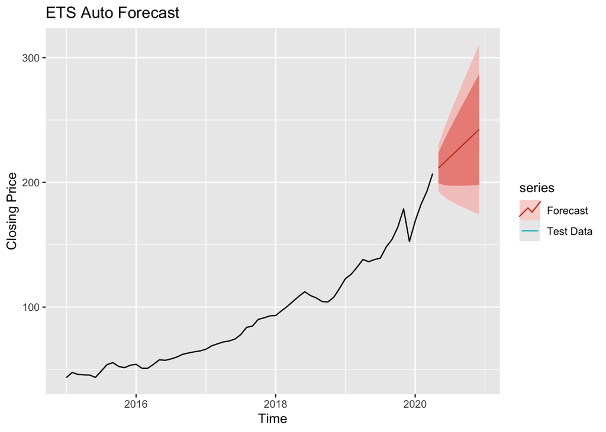

```r
autoplot(train) +
  autolayer(test, series = "Test Data") +
  autolayer(fc_auto, series = "Forecast", PI = TRUE) +
  ggtitle("ETS Auto Forecast") +
  ylab("Closing Price") + xlab("Time")
```

Оцінимо точність прогнозу

```r
accuracy(fc_auto, test)
```

```
##                      ME     RMSE      MAE        MPE     MAPE      MASE
## Training set  0.9087254 5.565040 3.331823  0.4980933 3.277276 0.1259432
## Test set     -6.5058424 8.450321 7.722240 -2.9857172 3.528005 0.2919013
##                     ACF1 Theil's U
## Training set -0.14071200        NA
## Test set     -0.08902285  1.144588
```

### ETS (M,A,A)

Зробимо прогноз

```r
fc_maa <- forecast(ets_maa_train, h = test_size)
```

Побудуємо графік пронозу

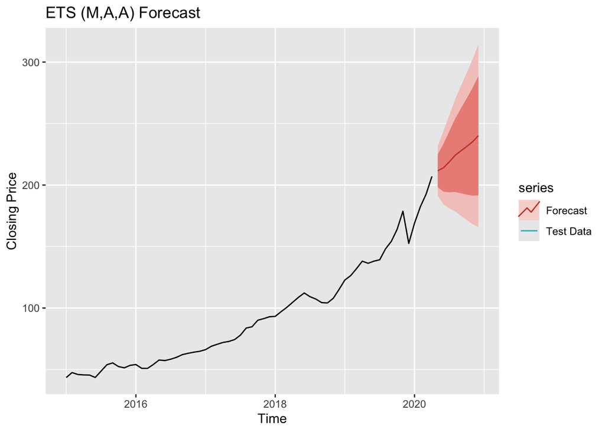

```r
autoplot(train) +
  autolayer(test, series = "Test Data") +
  autolayer(fc_maa, series = "Forecast", PI = TRUE) +
  ggtitle("ETS (M,A,A) Forecast") +
  ylab("Closing Price") + xlab("Time")
```

Оцінимо точність прогнозу

```r
accuracy(fc_maa, test)
```

```
##                      ME     RMSE      MAE        MPE     MAPE      MASE
## Training set  0.9589711 5.520203 3.278487  0.6533347 3.185574 0.1239271
## Test set     -4.9437173 7.288739 6.845880 -2.2883423 3.115142 0.2587748
##                     ACF1 Theil's U
## Training set -0.16569562        NA
## Test set     -0.03364225  0.988093
```

### ETS (M,A,M)

Зробимо прогноз

```r
fc_mam <- forecast(ets_mam_train, h = test_size)
```

Побудуємо графік пронозу

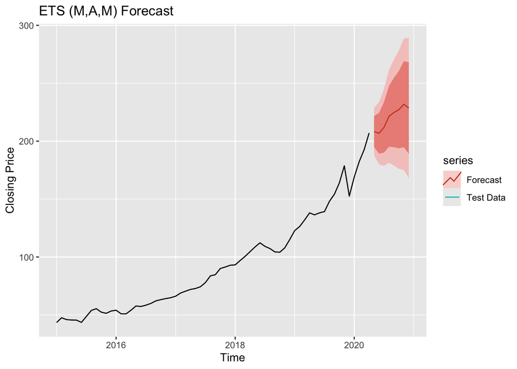

```r
autoplot(train) +
  autolayer(test, series = "Test Data") +
  autolayer(fc_mam, series = "Forecast", PI = TRUE) +
  ggtitle("ETS (M,A,M) Forecast") +
  ylab("Closing Price") + xlab("Time")
```

Оцінимо точність прогнозу

```r
accuracy(fc_mam, test)
```

```
##                    ME     RMSE      MAE       MPE     MAPE      MASE       ACF1
## Training set 1.329424 4.978652 3.392766 1.0989452 3.415306 0.1282468 0.03327277
## Test set     0.377163 5.694701 5.183743 0.1205472 2.329734 0.1959459 0.36112521
##              Theil's U
## Training set        NA
## Test set     0.7138935
```

### Aдитивна модель Холта – Уінтерса з лінійним трендом

Зробимо прогноз

```r
fc_hw_add <- forecast(hw_add_train, h = test_size)
```

Побудуємо графік пронозу

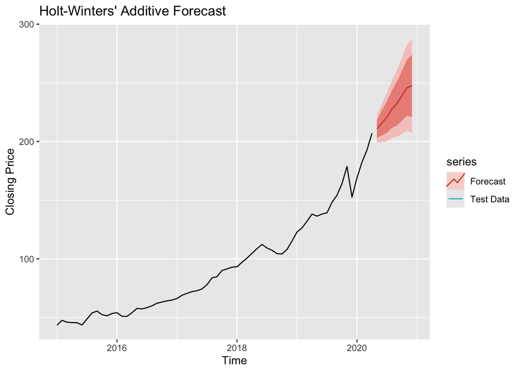

```r
autoplot(train) +
  autolayer(test, series = "Test Data") +
  autolayer(fc_hw_add, series = "Forecast", PI = TRUE) +
  ggtitle("Holt-Winters' Additive Forecast") +
  ylab("Closing Price") + xlab("Time")
```

Оцінимо точність прогнозу

```r
accuracy(fc_hw_add, test)
```

```
##                     ME      RMSE       MAE       MPE     MAPE      MASE
## Training set  1.087394  5.202253  3.481864  1.038075 3.754207 0.1316148
## Test set     -9.493302 11.363832 10.411300 -4.293143 4.721407 0.3935480
##                     ACF1 Theil's U
## Training set -0.05608947        NA
## Test set      0.13068762  1.527686
```

### Адитивна модель Холта – Уінтерса з демпфованим трендом

Зробимо прогноз

```r
fc_hw_add_damp <- forecast(hw_add_damp_train, h = test_size)
```

Побудуємо графік пронозу

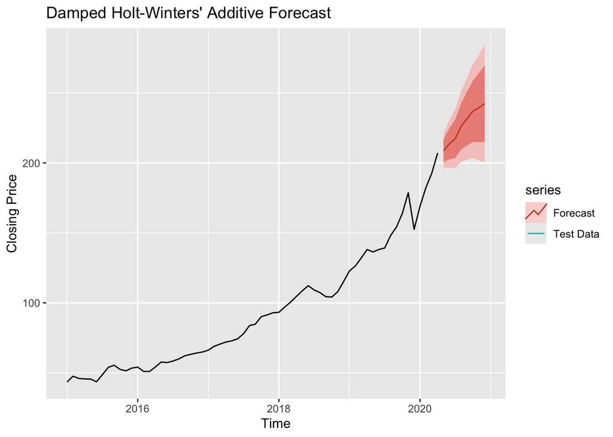

```r
autoplot(train) +
  autolayer(test, series = "Test Data") +
  autolayer(fc_hw_add_damp, series = "Forecast", PI = TRUE) +
  ggtitle("Damped Holt-Winters' Additive Forecast") +
  ylab("Closing Price") + xlab("Time")
```

Оцінимо точність прогнозу

```r
accuracy(fc_hw_add_damp, test)
```

```
##                      ME     RMSE      MAE        MPE     MAPE      MASE
## Training set  0.8579477 5.493985 3.535476  0.3625282 3.725405 0.1336413
## Test set     -6.5757250 9.416373 8.136244 -2.9965749 3.716823 0.3075507
##                     ACF1 Theil's U
## Training set -0.01262642        NA
## Test set      0.10004221  1.255291
```

### Мультиплікативна модель Холта – Уінтерса з лінійним трендом

Зробимо прогноз

```r
fc_hw_mult <- forecast(hw_mult_train, h = test_size)
```

Побудуємо графік пронозу

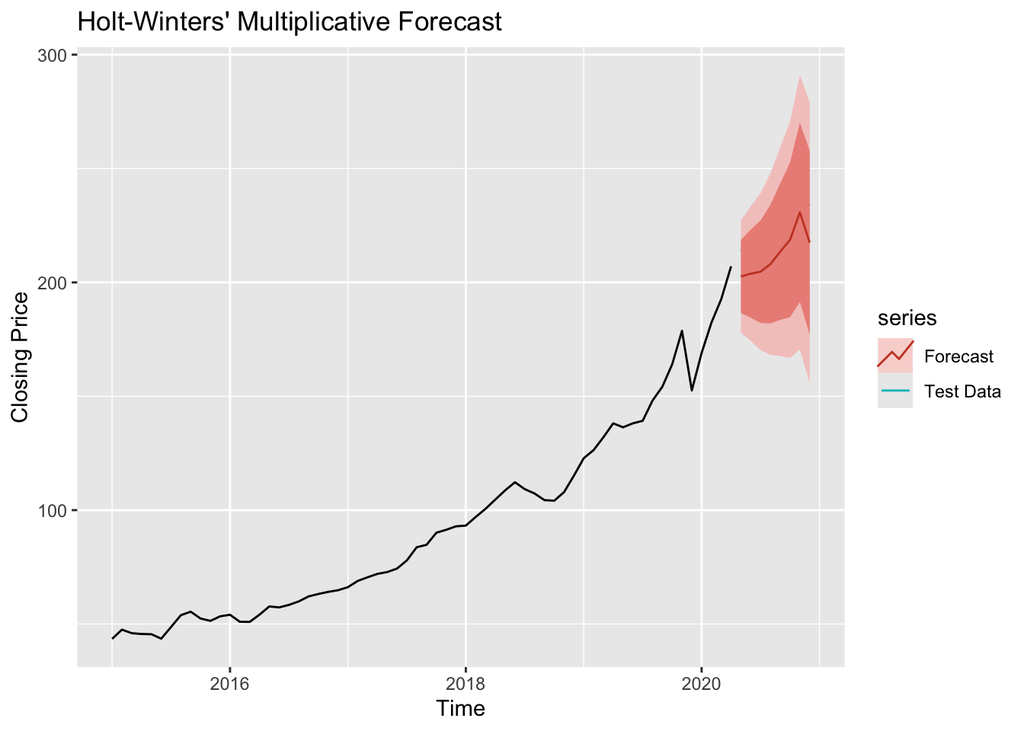

```r
autoplot(train) +
  autolayer(test, series = "Test Data") +
  autolayer(fc_hw_mult, series = "Forecast", PI = TRUE) +
  ggtitle("Holt-Winters' Multiplicative Forecast") +
  ylab("Closing Price") + xlab("Time")
```

Оцінимо точність прогнозу

```r
accuracy(fc_hw_mult, test)
```

```
##                    ME     RMSE      MAE       MPE     MAPE      MASE      ACF1
## Training set 1.032766 4.529226 3.579428 0.9165983 4.203381 0.1353027 0.2265996
## Test set     8.031284 8.991238 8.031284 3.6110335 3.611034 0.3035832 0.1226887
##              Theil's U
## Training set        NA
## Test set       1.04148
```

### Мультиплікативна модель Холта – Уінтерса з демпфованим трендом

Зробимо прогноз

```r
fc_hw_mult_damp <- forecast(hw_mult_damp_train, h = test_size)
```

Побудуємо графік пронозу

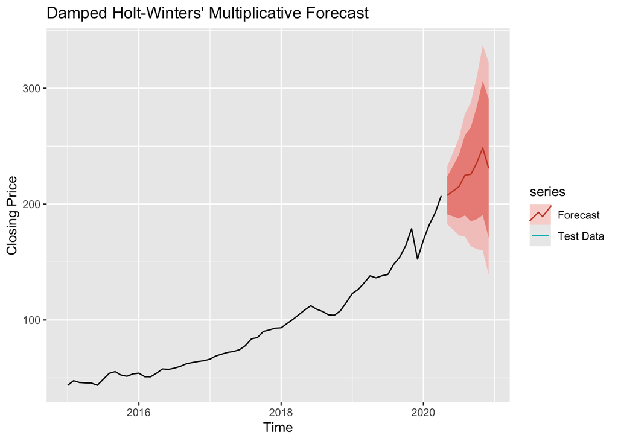

```r
autoplot(train) +
  autolayer(test, series = "Test Data") +
  autolayer(fc_hw_mult_damp, series = "Forecast", PI = TRUE) +
  ggtitle("Damped Holt-Winters' Multiplicative Forecast") +
  ylab("Closing Price") + xlab("Time")
```

Оцінимо точність прогнозу

```r
accuracy(fc_hw_mult_damp, test)
```

```
##                     ME     RMSE      MAE        MPE     MAPE      MASE
## Training set  0.638023 4.484524 3.350147  0.2538987 3.954846 0.1266358
## Test set     -4.429313 7.886871 6.850579 -1.9981099 3.100552 0.2589524
##                   ACF1 Theil's U
## Training set 0.1432703        NA
## Test set     0.2134486  1.026018
```

### ETC (A,A,A)

Зробимо прогноз

```r
fc_aaa <- forecast(ets_aaa_train, h = test_size)
```

Побудуємо графік пронозу

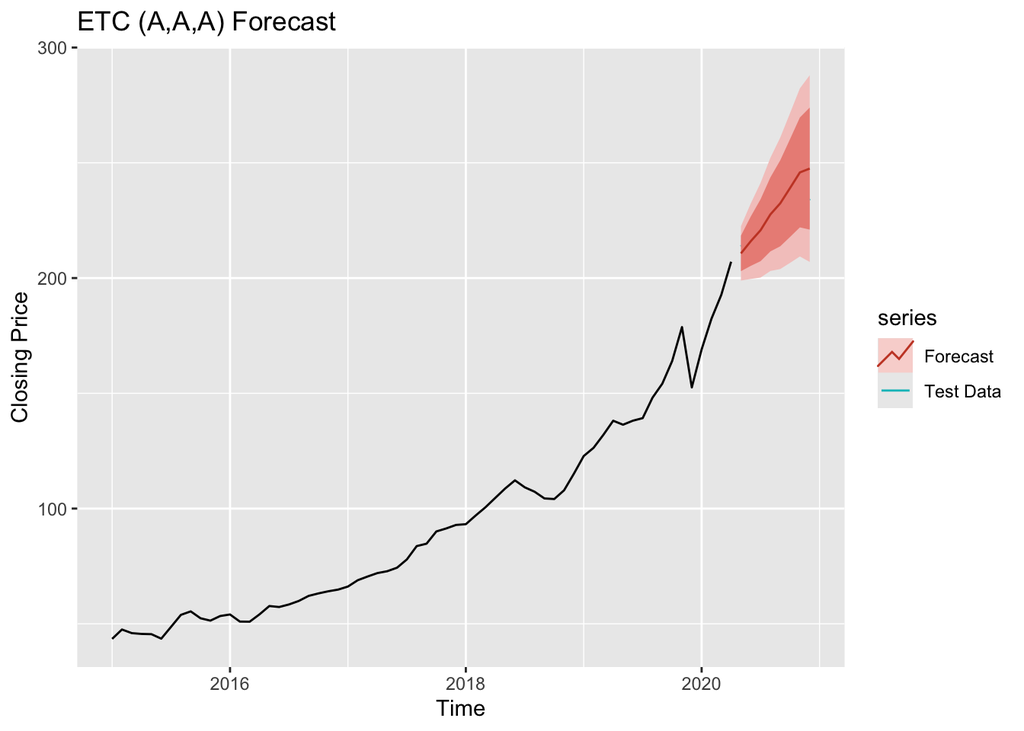

```r
autoplot(train) +
  autolayer(test, series = "Test Data") +
  autolayer(fc_aaa, series = "Forecast", PI = TRUE) +
  ggtitle("ETC (A,A,A) Forecast") +
  ylab("Closing Price") + xlab("Time")
```

Оцінимо точність прогнозу

```r
accuracy(fc_aaa, test)
```

```
##                     ME      RMSE       MAE       MPE     MAPE      MASE
## Training set  1.087394  5.202253  3.481864  1.038075 3.754207 0.1316148
## Test set     -9.493302 11.363832 10.411300 -4.293143 4.721407 0.3935480
##                     ACF1 Theil's U
## Training set -0.05608947        NA
## Test set      0.13068762  1.527686
```

### ETC (A,Ad,A)

Зробимо прогноз

```r
fc_aa_da <- forecast(ets_aa_da_train, h = test_size)
```

Побудуємо графік пронозу

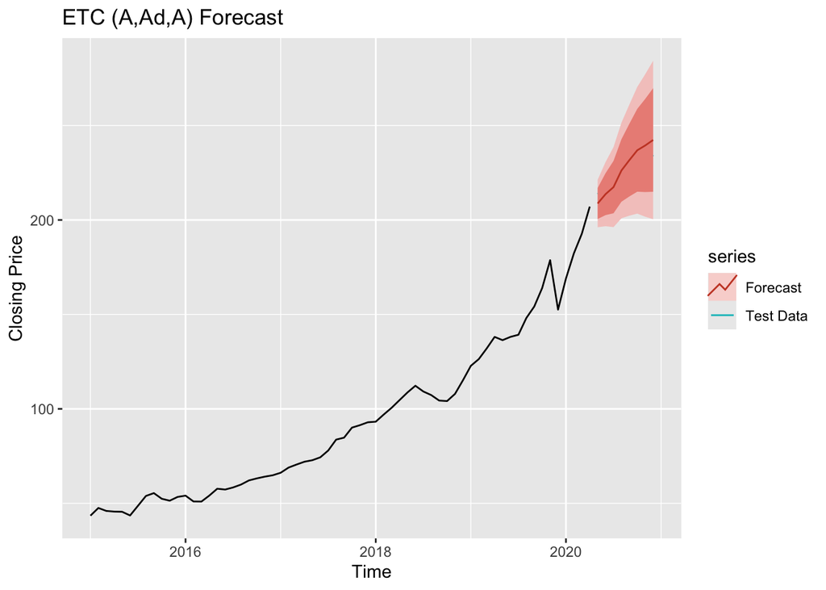

```r
autoplot(train) +
  autolayer(test, series = "Test Data") +
  autolayer(fc_aa_da, series = "Forecast", PI = TRUE) +
  ggtitle("ETC (A,Ad,A) Forecast") +
  ylab("Closing Price") + xlab("Time")
```

Оцінимо точність прогнозу

```r
accuracy(fc_aa_da, test)
```

```
##                      ME     RMSE      MAE        MPE     MAPE      MASE
## Training set  0.8579477 5.493985 3.535476  0.3625282 3.725405 0.1336413
## Test set     -6.5757250 9.416373 8.136244 -2.9965749 3.716823 0.3075507
##                     ACF1 Theil's U
## Training set -0.01262642        NA
## Test set      0.10004221  1.255291
```

### ETC (M,Ad,A)

Зробимо прогноз

```r
fc_ma_da <- forecast(ets_ma_da_train, h = test_size)
```

Побудуємо графік пронозу

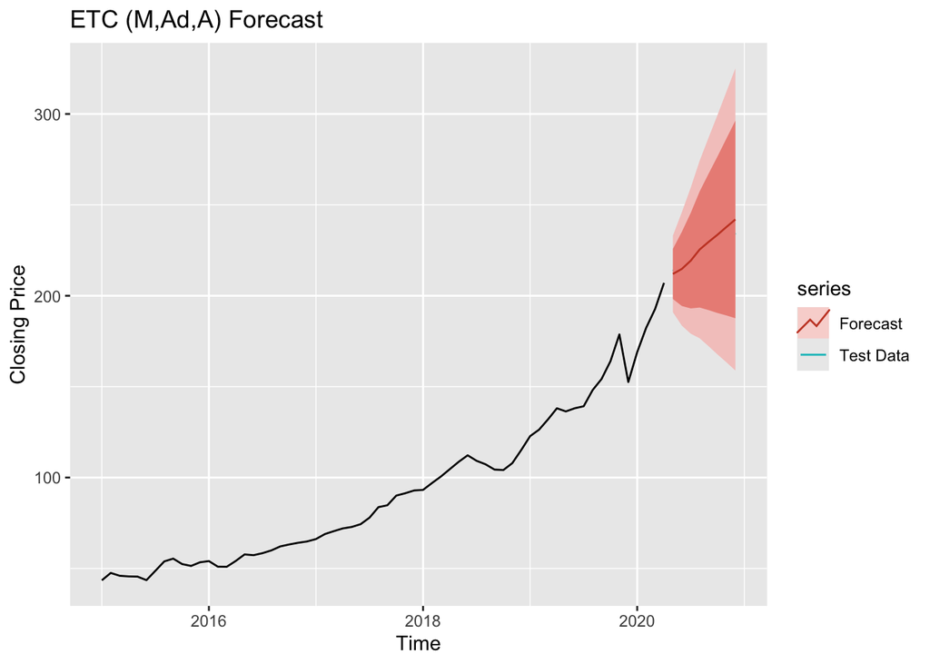

```r
autoplot(train) +
  autolayer(test, series = "Test Data") +
  autolayer(fc_ma_da, series = "Forecast", PI = TRUE) +
  ggtitle("ETC (M,Ad,A) Forecast") +
  ylab("Closing Price") + xlab("Time")
```

Оцінимо точність прогнозу

```r
accuracy(fc_ma_da, test)
```

```
##                      ME    RMSE      MAE        MPE     MAPE      MASE
## Training set  0.9159399 5.60093 3.298730  0.5340915 3.217389 0.1246922
## Test set     -6.3440292 8.33581 7.485623 -2.9113265 3.416184 0.2829572
##                     ACF1 Theil's U
## Training set -0.16773840        NA
## Test set     -0.01549616  1.132347
```

### ETC (M,Ad,M)

Зробимо прогноз

```r
fc_ma_dm <- forecast(ets_ma_dm_train, h = test_size)
```

Побудуємо графік пронозу

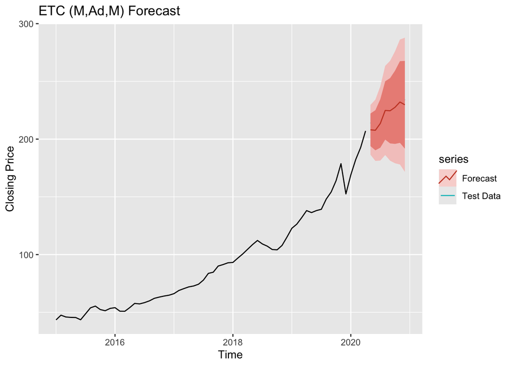

```r
autoplot(train) +
  autolayer(test, series = "Test Data") +
  autolayer(fc_ma_dm, series = "Forecast", PI = TRUE) +
  ggtitle("ETC (M,Ad,M) Forecast") +
  ylab("Closing Price") + xlab("Time")
```

Оцінимо точність прогнозу

```r
accuracy(fc_ma_dm, test)
```

```
##                      ME     RMSE      MAE        MPE     MAPE      MASE
## Training set  1.3986780 5.229427 3.661734  0.9603222 3.717154 0.1384138
## Test set     -0.5340633 6.215243 5.355307 -0.2992033 2.414887 0.2024310
##                   ACF1 Theil's U
## Training set 0.1824572        NA
## Test set     0.3255101 0.7928809
```

### Оцінка якості прогнозу

Отримали таку таблицю

|  | MAPE (train) | MASE (train) | MAPE (test) | MASE (test) |
| --- | --- | --- | --- | --- |
| **ETS Auto** | 3.277% | 0.126 | 3.528% | 0.292 |
| **ETS (M,A,A)** | 3.186% | 0.124 | 3.115% | 0.259 |
| **ETS (M,A,M)** | 3.415% | 0.128 | 2.33% | 0.196 |
| **Aдитивна модель Холта – Уінтерса з лінійним трендом** | 3.754% | 0.132 | 4.721% | 0.394 |
| **Адитивна модель Холта – Уінтерса з демпфованим трендом** | 3.725% | 0.134 | 3.717% | 0.308 |
| **Мультиплікативна модель Холта – Уінтерса з лінійним трендом** | 4.203% | 0.135 | 3.611% | 0.304 |
| **Мультиплікативна модель Холта – Уінтерса з демпфованим трендом** | 3.955% | 0.127 | 3.101% | 0.259 |
| **ETS (A,A,A)** | 3.754% | 0.132 | 4.721% | 0.394 |
| **ETS (A,Ad,A)** | 3.725% | 0.134 | 3.717% | 0.308 |
| **ETS (M,Ad,A)** | 3.217% | 0.125 | 3.416% | 0.283 |
| **ETS (M,Ad,M)** | 3.717% | 0.138 | 2.415% | 0.202 |

## 5 Побудова графіка вихідного та згладженого часового ряду

Побудуємо графіки вихідного та згладженого часового ряду для найкращих моделей

### ETS Auto

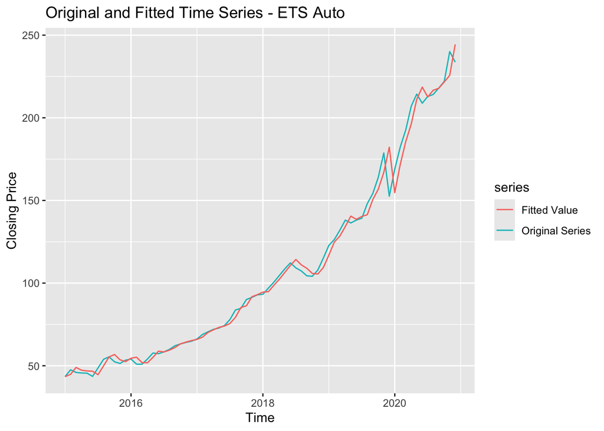

```r
autoplot(msft_ts_monthly, series = "Original Series") +
  autolayer(fitted(ets_auto), series = "Fitted Value") +
  ggtitle("Original and Fitted Time Series - ETS Auto") +
  ylab("Closing Price") + xlab("Time")
```

### ETS (M,A,A)

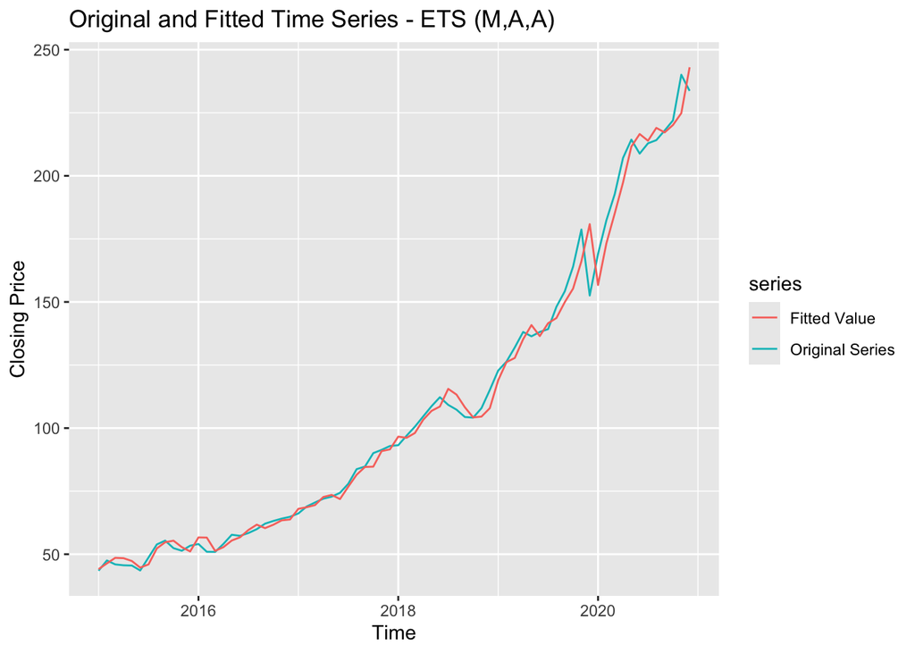

```r
autoplot(msft_ts_monthly, series = "Original Series") +
  autolayer(fitted(ets_maa_model), series = "Fitted Value") +
  ggtitle("Original and Fitted Time Series - ETS (M,A,A)") +
  ylab("Closing Price") + xlab("Time")
```

### ETS (M,A,M)

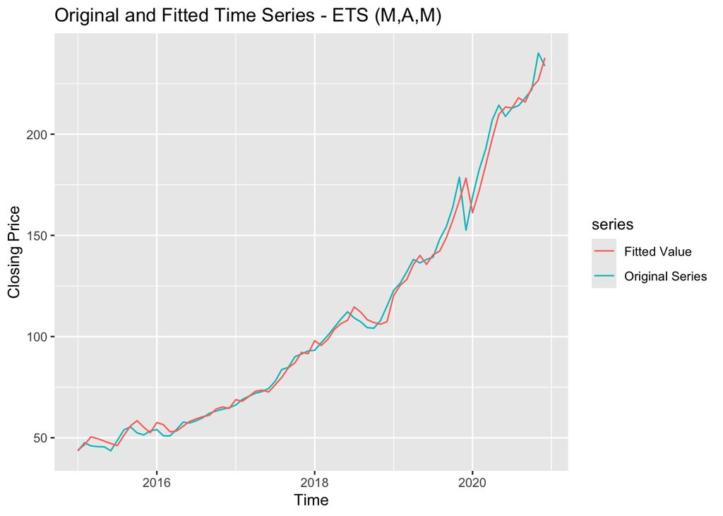

```r
autoplot(msft_ts_monthly, series = "Original Series") +
  autolayer(fitted(ets_mam_model), series = "Fitted Value") +
  ggtitle("Original and Fitted Time Series - ETS (M,A,M)") +
  ylab("Closing Price") + xlab("Time")
```

## 6 Побудова графіків окремих компонентів часового ряду

### ETS Auto

Побудуємо графік окремих компонентів часового ряду

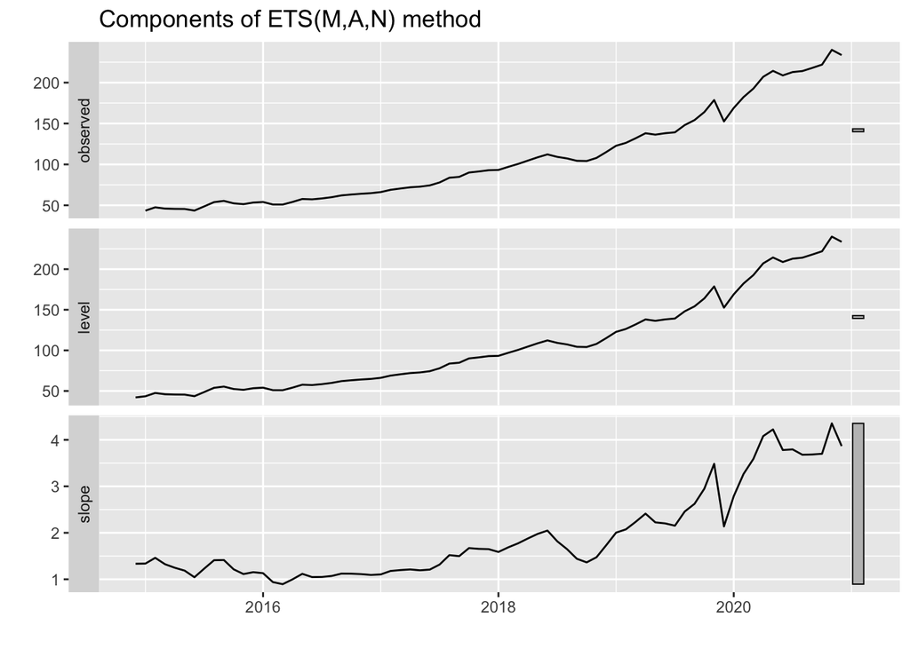

```r
autoplot(ets_auto)
```

На графіку компонента **observed** - це вихідний часовий ряд, **level** - компонента рівня, **slope** - тренд (нахил). Можна побачити різкий стрибок нахилу в ковідні часи. Велике значення $\alpha = 1$ призвело до того, що графік згладженого рівня майже ідентичний графіку вихідного тимчасового ряду.

Побудуємо тепер графіки залишків моделі

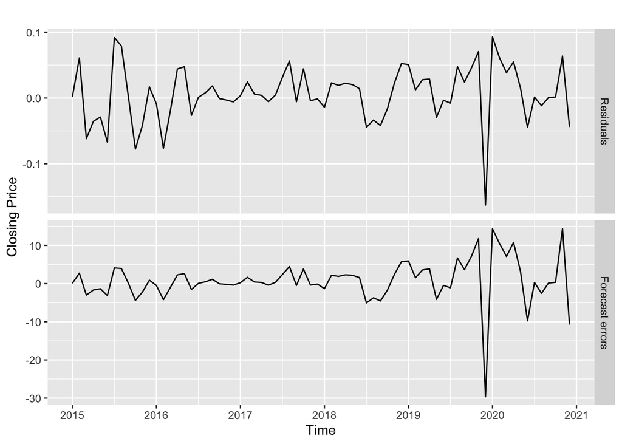

```r
cbind('Residuals' = residuals(ets_auto),
'Forecast errors' = residuals(ets_auto, type='response')) %>%
autoplot(facet=TRUE) + xlab("Time") + ylab("Closing Price")
```

Зауважимо, що у разі мультиплікативних помилок залишки моделі та помилки прогнозу неідентичні. Графік це показує.

### ETS $(M,A,A)$

Побудуємо графік окремих компонентів часового ряду

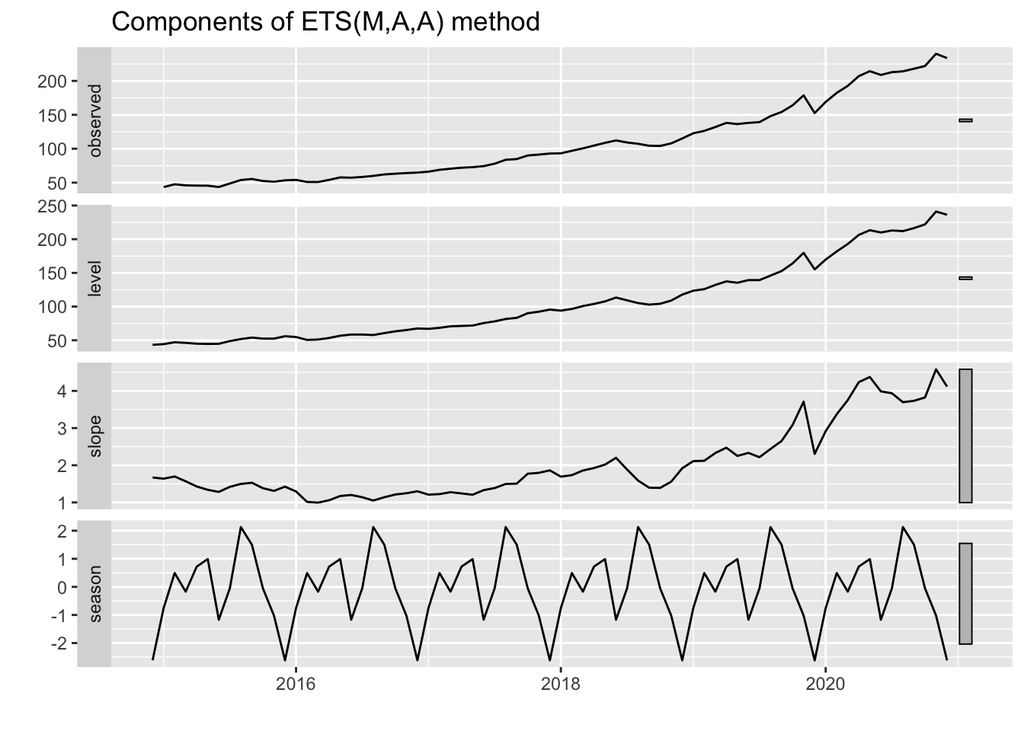

```r
autoplot(ets_maa_model)
```

На графіку бачимо такі ж самі компоненти: **observed**, **level**, **slope**. До них ще додається компанента **season**, яка відображає сезонні коливання.

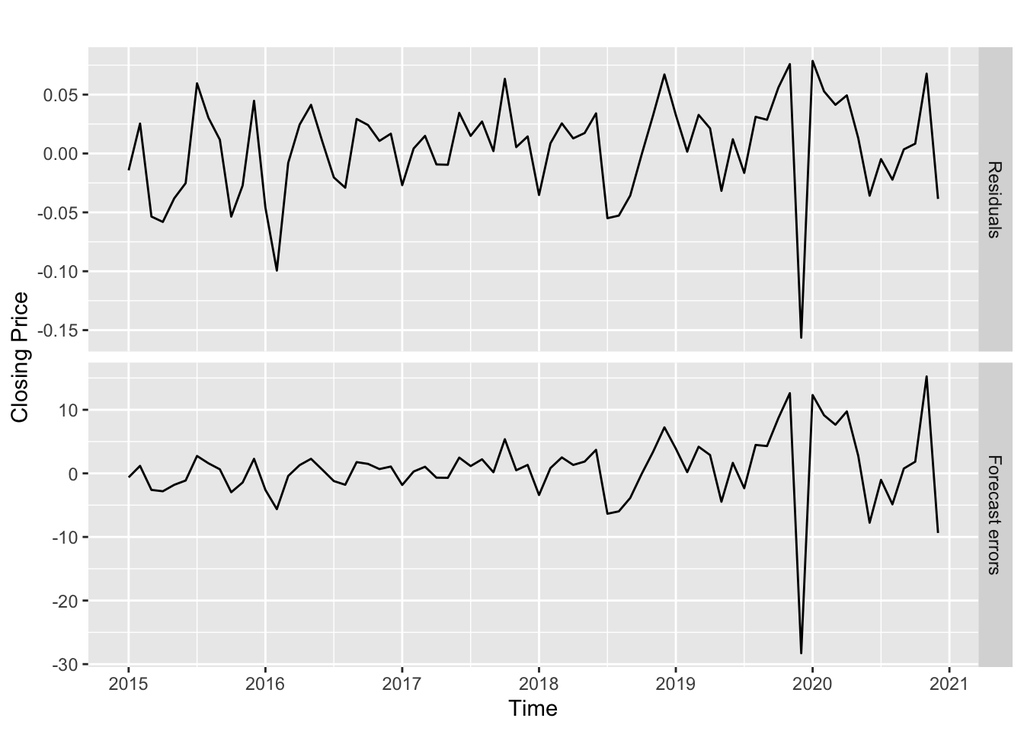

```r
cbind('Residuals' = residuals(ets_maa_model),
'Forecast errors' = residuals(ets_maa_model, type='response')) %>%
autoplot(facet=TRUE) + xlab("Time") + ylab("Closing Price")
```

### ETS $(M,A,M)$

Побудуємо графік окремих компонентів часового ряду

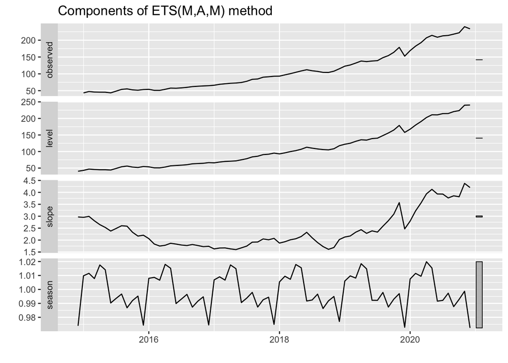

```r
autoplot(ets_mam_model)
```

На графіку бачимо такі ж самі компоненти: **observed**, **level**, **slope**, **season**.

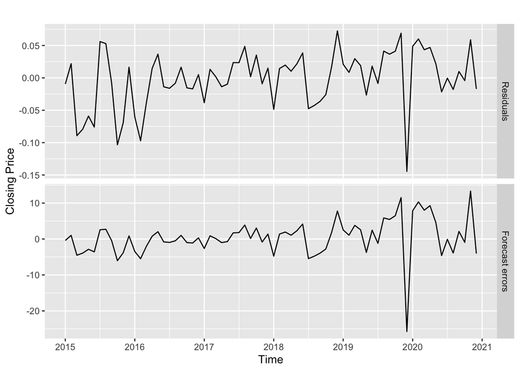

```r
cbind('Residuals' = residuals(ets_mam_model),
'Forecast errors' = residuals(ets_mam_model, type='response')) %>%
autoplot(facet=TRUE) + xlab("Time") + ylab("Closing Price")
```

## Висновок

Було побудовано 11 різних моделей експоненційного згладжування: чотири варіанти моделей Холта-Уінтерса (адитивна та мультиплікативна, з лінійним та демпфованим трендом), шість специфікованих ETS-моделей та одна автоматично підібрана модель. Було проведено навчання моделей та прогнозування. На повному наборі даних найкращі результати показали моделі з мультиплікативними помилками ETS Auto, ETS(M,A,A) та ETS(M,A,M). Це підтвердило, що для фінансових даних з високою волатильністю мультиплікативна структура помилок є більш адекватною. Декомпозиція часових рядів показала наявність чітко вираженого зростаючого тренду з різким стрибком у 2020 році.

Для прогнозування цін акцій Microsoft рекомендується використовувати модель ETS (M,A,M) з мультиплікативними помилками, адитивним трендом та мультиплікативною сезонністю. Ця модель демонструє найкращу узагальнюючу здатність (MAPE на тестових даних на $1\%$ нижчий, ніж на навчальних) та найвищу точність прогнозування серед усіх розглянутих варіантів.